# 特殊直角三角形與面積

> 來源整理：改國二下7_三角形的邊角關係_易讀版.md

## 特殊直角三角形：30-60-90 與 45-45-90

> 學習目標：特殊直角三角形把角度和邊長比例直接連起來，是後面面積與立體題的省力工具。

### 先抓住核心

- 30-60-90 三角形邊長比為 1 : sqrt(3) : 2。
- 45-45-90 三角形邊長比為 1 : 1 : sqrt(2)。
- 30° 對面的邊最短，90° 對面的斜邊最長。
- 45-45-90 是等腰直角三角形，兩股相等。
- 使用比例時要先確認哪個角對哪條邊。

### 解題流程

1. 先確認直角三角形角度。
2. 判斷是 30-60-90 還是 45-45-90。
3. 標出最短邊或一股作為比例 1。
4. 依比例求其他邊。
5. 需要面積時再代入底高。

### 公式、性質與判斷

- **30-60-90**：短股 : 長股 : 斜邊 = 1 : sqrt(3) : 2。
- **45-45-90**：股 : 股 : 斜邊 = 1 : 1 : sqrt(2)。
- **斜邊**：直角對邊，最大邊。

### 例題拆解

- 若 30-60-90 三角形斜邊為 4，短股為 2，長股為 2sqrt(3)。
- 若 45-45-90 三角形一股為 5，斜邊為 5sqrt(2)。
- 長方體對角線題若邊長比化成 1:sqrt(3):2，可判斷對應角為 60°。

### 易錯提醒

- 把 sqrt(3) 放到 30° 對邊。
- 忘記 45-45-90 的兩股相等。

### 小練一下

- 30-60-90 三角形中，30° 對邊若為 3，斜邊是多少？
- 45-45-90 三角形中，一股為 4，斜邊是多少？

### 記憶鉤子

- 特殊直角三角形先認角，再套比例。
- 30 度對 1，60 度對 sqrt(3)，90 度對 2。

### 圖像化理解

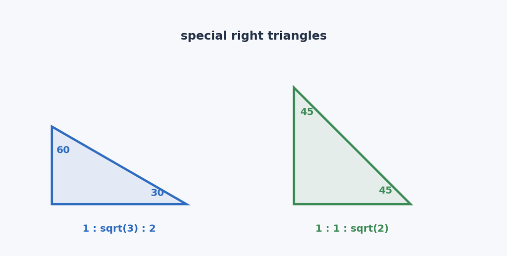

特殊直角三角形：30-60-90 與 45-45-90

圖解：並排標示 30-60-90 與 45-45-90 的邊長比例。

## 特殊直角三角形與面積

> 學習目標：看到正方形、剪去直角三角形、剩下面積，通常要先找特殊直角三角形的邊長。

### 先抓住核心

- 正方形面積是邊長平方。
- 剪去三角形後的面積 = 原圖形面積 - 被剪去三角形面積。
- 若剪去的是 30-60-90 三角形，可用 1:sqrt(3):2 求兩股。
- 三角形面積是底*高/2。
- 根號面積答案要保留根號，不要硬改小數。

### 解題流程

1. 先算原圖形面積。
2. 辨認被剪去的直角三角形類型。
3. 用特殊比例求兩股。
4. 算三角形面積。
5. 用原面積扣掉剪去面積。

### 公式、性質與判斷

- **正方形面積**：side^2。
- **三角形面積**：base*height/2。
- **例**：16 - 2sqrt(3)。

### 例題拆解

- 邊長 4 的正方形面積是 16。
- 若剪去三角形兩股為 2 與 2sqrt(3)，面積是 2sqrt(3)。
- 剩下面積就是 16 - 2sqrt(3)。

### 易錯提醒

- 把斜邊拿去當三角形面積的高。
- 扣面積時漏掉三角形面積要除以 2。

### 小練一下

- 邊長 6 的正方形面積是多少？
- 兩股為 3 與 3sqrt(3) 的直角三角形面積是多少？

### 記憶鉤子

- 面積題先分成原本和剪掉兩塊。
- 特殊直角比例求邊，面積公式收尾。

### 圖像化理解

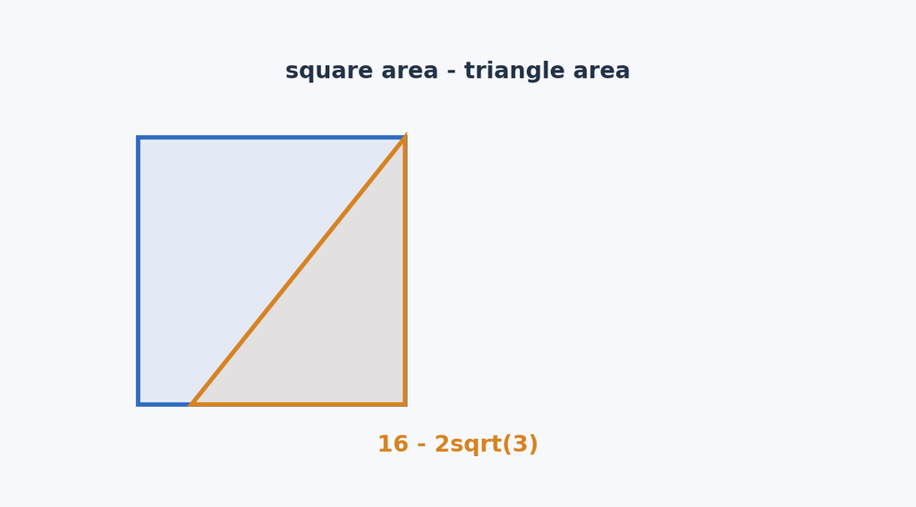

特殊直角三角形與面積

圖解：用正方形剪去 30-60-90 三角形示意剩下面積。

## 長方體對角線與特殊直角三角形

> 學習目標：立體題可以拆成平面直角三角形，再用畢氏與特殊比例判斷角度。

### 先抓住核心

- 長方體空間對角線題常先在底面算一條對角線。
- 底面對角線與高度再形成另一個直角三角形。
- 若邊長比化成 1:sqrt(3):2，就可判斷角度為 30-60-90。
- 原講義例子中 AB=2、AD=2sqrt(3)、BD=4，比例為 1:sqrt(3):2。
- 因此對應的 60° 可由特殊直角三角形比例判斷。

### 解題流程

1. 先把立體圖形拆成直角三角形。
2. 用畢氏定理求平面或空間對角線。
3. 把邊長比約成最簡比例。
4. 比對 30-60-90 或 45-45-90。
5. 回到題目指定的角。

### 例題拆解

- 若 AB=2、AD=2sqrt(3)、BD=4，則 AB:AD:BD=1:sqrt(3):2。
- 因此這個直角三角形是 30-60-90。
- 若題目角對應 sqrt(3) 的邊，就可判斷為 60°。

### 易錯提醒

- 直接在立體圖上猜角度。
- 底面對角線還沒算出來就套特殊比例。

### 小練一下

- 1:sqrt(3):2 是哪一種特殊直角三角形？
- 立體對角線題通常要先拆成什麼？

### 記憶鉤子

- 立體圖不要硬看，拆成直角三角形就會降維。
- 比例化簡後再認特殊角。

### 圖像化理解

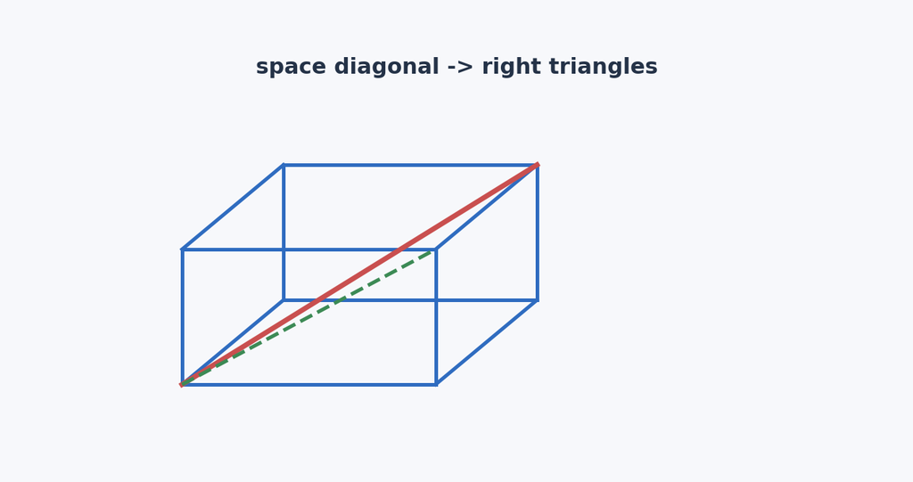

長方體對角線與特殊直角三角形

圖解：用長方體拆成兩個直角三角形，示意空間對角線與特殊比例。